# Risk Factor Analysis

## Outcome Variable

**Outcome Variable:** ever_stunted

## Predictor Variables

**Intervention Variable:** nhh

**Adjustment Set:**

unadjusted

## Stratifying Variables

The analysis was stratified on these variable(s):

- agecat
- studyid
- country

## Data Summary

| agecat | studyid | country | A | n | nA | nAY0 | nAY1 |
| --- | --- | --- | --- | --- | --- | --- | --- |
| 3 months | ki1000108-IRC | INDIA | 3 or less | 410 | 58 | 44 | 14 |
| 3 months | ki1000108-IRC | INDIA | 4-5 | 410 | 158 | 103 | 55 |
| 3 months | ki1000108-IRC | INDIA | 6-7 | 410 | 107 | 73 | 34 |
| 3 months | ki1000108-IRC | INDIA | 8+ | 410 | 87 | 60 | 27 |
| 3 months | ki1017093-NIH-Birth | BANGLADESH | 3 or less | 629 | 117 | 93 | 24 |
| 3 months | ki1017093-NIH-Birth | BANGLADESH | 4-5 | 629 | 264 | 200 | 64 |
| 3 months | ki1017093-NIH-Birth | BANGLADESH | 6-7 | 629 | 142 | 113 | 29 |
| 3 months | ki1017093-NIH-Birth | BANGLADESH | 8+ | 629 | 106 | 83 | 23 |
| 3 months | ki1017093b-PROVIDE | BANGLADESH | 3 or less | 700 | 140 | 118 | 22 |
| 3 months | ki1017093b-PROVIDE | BANGLADESH | 4-5 | 700 | 322 | 256 | 66 |
| 3 months | ki1017093b-PROVIDE | BANGLADESH | 6-7 | 700 | 151 | 123 | 28 |
| 3 months | ki1017093b-PROVIDE | BANGLADESH | 8+ | 700 | 87 | 73 | 14 |
| 3 months | ki1017093c-NIH-Crypto | BANGLADESH | 3 or less | 758 | 114 | 91 | 23 |
| 3 months | ki1017093c-NIH-Crypto | BANGLADESH | 4-5 | 758 | 342 | 291 | 51 |
| 3 months | ki1017093c-NIH-Crypto | BANGLADESH | 6-7 | 758 | 178 | 150 | 28 |
| 3 months | ki1017093c-NIH-Crypto | BANGLADESH | 8+ | 758 | 124 | 105 | 19 |
| 6 months | ki1000108-IRC | INDIA | 3 or less | 408 | 58 | 36 | 22 |
| 6 months | ki1000108-IRC | INDIA | 4-5 | 408 | 158 | 83 | 75 |
| 6 months | ki1000108-IRC | INDIA | 6-7 | 408 | 105 | 64 | 41 |
| 6 months | ki1000108-IRC | INDIA | 8+ | 408 | 87 | 52 | 35 |
| 6 months | ki1000304b-SAS-FoodSuppl | INDIA | 3 or less | 105 | 9 | 5 | 4 |
| 6 months | ki1000304b-SAS-FoodSuppl | INDIA | 4-5 | 105 | 41 | 23 | 18 |
| 6 months | ki1000304b-SAS-FoodSuppl | INDIA | 6-7 | 105 | 36 | 22 | 14 |
| 6 months | ki1000304b-SAS-FoodSuppl | INDIA | 8+ | 105 | 19 | 12 | 7 |
| 6 months | ki1017093-NIH-Birth | BANGLADESH | 3 or less | 551 | 100 | 64 | 36 |
| 6 months | ki1017093-NIH-Birth | BANGLADESH | 4-5 | 551 | 236 | 145 | 91 |
| 6 months | ki1017093-NIH-Birth | BANGLADESH | 6-7 | 551 | 122 | 74 | 48 |
| 6 months | ki1017093-NIH-Birth | BANGLADESH | 8+ | 551 | 93 | 67 | 26 |
| 6 months | ki1017093b-PROVIDE | BANGLADESH | 3 or less | 640 | 119 | 90 | 29 |
| 6 months | ki1017093b-PROVIDE | BANGLADESH | 4-5 | 640 | 299 | 218 | 81 |

[output cut: 82 more lines]

The following strata were considered:

- agecat: 12 months, studyid: ki1000108-IRC, country: INDIA
- agecat: 12 months, studyid: ki1000304b-SAS-FoodSuppl, country: INDIA
- agecat: 12 months, studyid: ki1017093-NIH-Birth, country: BANGLADESH
- agecat: 12 months, studyid: ki1017093b-PROVIDE, country: BANGLADESH
- agecat: 12 months, studyid: ki1017093c-NIH-Crypto, country: BANGLADESH
- agecat: 12 months, studyid: ki1148112-LCNI-5, country: MALAWI
- agecat: 18 months, studyid: ki1000108-IRC, country: INDIA
- agecat: 18 months, studyid: ki1000304b-SAS-FoodSuppl, country: INDIA
- agecat: 18 months, studyid: ki1017093-NIH-Birth, country: BANGLADESH
- agecat: 18 months, studyid: ki1017093b-PROVIDE, country: BANGLADESH
- agecat: 18 months, studyid: ki1017093c-NIH-Crypto, country: BANGLADESH
- agecat: 18 months, studyid: ki1148112-LCNI-5, country: MALAWI
- agecat: 24 months, studyid: ki1000108-IRC, country: INDIA
- agecat: 24 months, studyid: ki1000304b-SAS-FoodSuppl, country: INDIA
- agecat: 24 months, studyid: ki1017093-NIH-Birth, country: BANGLADESH
- agecat: 24 months, studyid: ki1017093b-PROVIDE, country: BANGLADESH
- agecat: 24 months, studyid: ki1017093c-NIH-Crypto, country: BANGLADESH
- agecat: 24 months, studyid: ki1148112-LCNI-5, country: MALAWI
- agecat: 3 months, studyid: ki1000108-IRC, country: INDIA
- agecat: 3 months, studyid: ki1017093-NIH-Birth, country: BANGLADESH
- agecat: 3 months, studyid: ki1017093b-PROVIDE, country: BANGLADESH
- agecat: 3 months, studyid: ki1017093c-NIH-Crypto, country: BANGLADESH
- agecat: 6 months, studyid: ki1000108-IRC, country: INDIA
- agecat: 6 months, studyid: ki1000304b-SAS-FoodSuppl, country: INDIA
- agecat: 6 months, studyid: ki1017093-NIH-Birth, country: BANGLADESH
- agecat: 6 months, studyid: ki1017093b-PROVIDE, country: BANGLADESH
- agecat: 6 months, studyid: ki1017093c-NIH-Crypto, country: BANGLADESH
- agecat: 6 months, studyid: ki1148112-LCNI-5, country: MALAWI

### Dropped Strata

Some strata were dropped due to rare outcomes:

- agecat: 6 months, studyid: ki1000304b-SAS-FoodSuppl, country: INDIA
- agecat: 6 months, studyid: ki1148112-LCNI-5, country: MALAWI
- agecat: 12 months, studyid: ki1000304b-SAS-FoodSuppl, country: INDIA
- agecat: 18 months, studyid: ki1000304b-SAS-FoodSuppl, country: INDIA
- agecat: 24 months, studyid: ki1000304b-SAS-FoodSuppl, country: INDIA

## Methods Detail

We’re interested in the causal parameters $E[Y_a]$ for all values of $a \in \mathcal{A}$. These parameters represent the mean outcome if, possibly contrary to fact, we intervened to set all units to have $A=a$. Under the randomization and positivity assumptions, these are identified by the statistical parameters $\psi_a=E_W[E_{Y|A,W}(Y|A=a,W)]$. In addition, we’re interested in the mean of $Y$, $E[Y]$ under no intervention (the observed mean). We will estimate these parameters by using SuperLearner to fit the relevant likelihood factors – $E_{Y|A,W}(Y|A=a,W)$ and $p(A=a|W)$, and then updating our likelihood fit using a joint TMLE.

For unadjusted analyses ($W=\{\}$), initial likelihoods were estimated using Lrnr_glm to estimate the simple $E(Y|A)$ and Lrnr_mean to estimate $p(A)$. For adjusted analyses, a small library containing Lrnr_glmnet, Lrnr_xgboost, and Lrnr_mean was used.

Having estimated these parameters, we will then use the delta method to estimate relative risks and attributable risks relative to a prespecified baseline level of $A$.

# Results Detail

## Results Plots

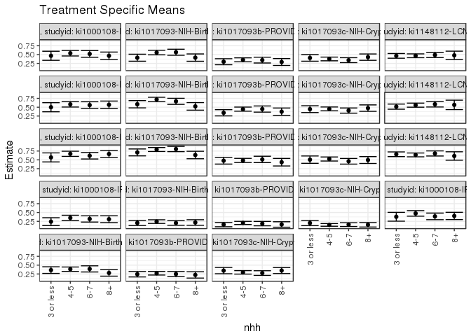

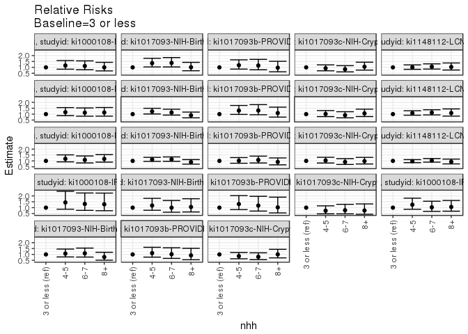

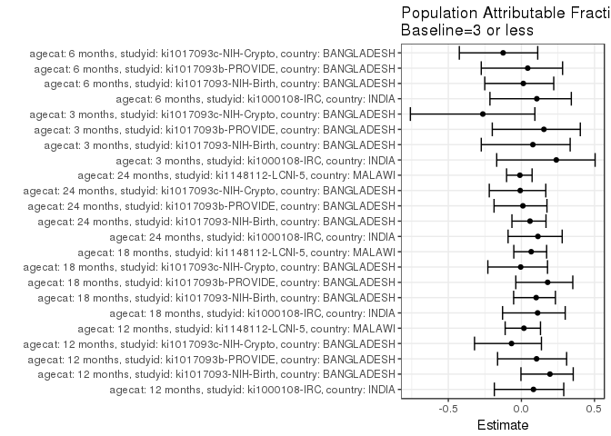

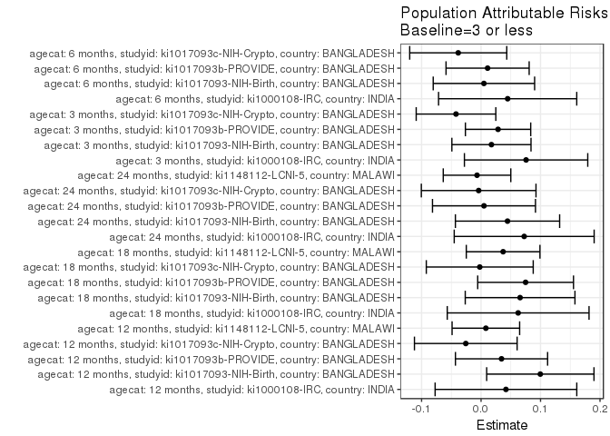

## Results Table

### Parameter: TSM

| agecat | studyid | country | intervention_level | baseline_level | estimate | ci_lower | ci_upper |
| --- | --- | --- | --- | --- | --- | --- | --- |
| 3 months | ki1000108-IRC | INDIA | 3 or less | NA | 0.2413793 | 0.1311171 | 0.3516415 |
| 3 months | ki1000108-IRC | INDIA | 4-5 | NA | 0.3481013 | 0.2737321 | 0.4224704 |
| 3 months | ki1000108-IRC | INDIA | 6-7 | NA | 0.3177570 | 0.2294280 | 0.4060861 |
| 3 months | ki1000108-IRC | INDIA | 8+ | NA | 0.3103448 | 0.2130125 | 0.4076771 |
| 3 months | ki1017093-NIH-Birth | BANGLADESH | 3 or less | NA | 0.2051282 | 0.1319028 | 0.2783536 |
| 3 months | ki1017093-NIH-Birth | BANGLADESH | 4-5 | NA | 0.2424242 | 0.1906883 | 0.2941602 |
| 3 months | ki1017093-NIH-Birth | BANGLADESH | 6-7 | NA | 0.2042254 | 0.1378664 | 0.2705843 |
| 3 months | ki1017093-NIH-Birth | BANGLADESH | 8+ | NA | 0.2169811 | 0.1384507 | 0.2955115 |
| 3 months | ki1017093b-PROVIDE | BANGLADESH | 3 or less | NA | 0.1571429 | 0.0968149 | 0.2174708 |
| 3 months | ki1017093b-PROVIDE | BANGLADESH | 4-5 | NA | 0.2049689 | 0.1608458 | 0.2490921 |
| 3 months | ki1017093b-PROVIDE | BANGLADESH | 6-7 | NA | 0.1854305 | 0.1233972 | 0.2474637 |
| 3 months | ki1017093b-PROVIDE | BANGLADESH | 8+ | NA | 0.1609195 | 0.0836506 | 0.2381885 |
| 3 months | ki1017093c-NIH-Crypto | BANGLADESH | 3 or less | NA | 0.2017544 | 0.1280383 | 0.2754704 |
| 3 months | ki1017093c-NIH-Crypto | BANGLADESH | 4-5 | NA | 0.1491228 | 0.1113458 | 0.1868998 |
| 3 months | ki1017093c-NIH-Crypto | BANGLADESH | 6-7 | NA | 0.1573034 | 0.1037817 | 0.2108250 |
| 3 months | ki1017093c-NIH-Crypto | BANGLADESH | 8+ | NA | 0.1532258 | 0.0897843 | 0.2166673 |
| 6 months | ki1000108-IRC | INDIA | 3 or less | NA | 0.3793103 | 0.2542840 | 0.5043367 |
| 6 months | ki1000108-IRC | INDIA | 4-5 | NA | 0.4746835 | 0.3967248 | 0.5526423 |
| 6 months | ki1000108-IRC | INDIA | 6-7 | NA | 0.3904762 | 0.2970478 | 0.4839046 |
| 6 months | ki1000108-IRC | INDIA | 8+ | NA | 0.4022989 | 0.2991326 | 0.5054651 |
| 6 months | ki1017093-NIH-Birth | BANGLADESH | 3 or less | NA | 0.3600000 | 0.2658362 | 0.4541638 |
| 6 months | ki1017093-NIH-Birth | BANGLADESH | 4-5 | NA | 0.3855932 | 0.3234378 | 0.4477487 |
| 6 months | ki1017093-NIH-Birth | BANGLADESH | 6-7 | NA | 0.3934426 | 0.3066787 | 0.4802066 |
| 6 months | ki1017093-NIH-Birth | BANGLADESH | 8+ | NA | 0.2795699 | 0.1882759 | 0.3708639 |
| 6 months | ki1017093b-PROVIDE | BANGLADESH | 3 or less | NA | 0.2436975 | 0.1665028 | 0.3208922 |
| 6 months | ki1017093b-PROVIDE | BANGLADESH | 4-5 | NA | 0.2709030 | 0.2204890 | 0.3213171 |
| 6 months | ki1017093b-PROVIDE | BANGLADESH | 6-7 | NA | 0.2481752 | 0.1757875 | 0.3205629 |
| 6 months | ki1017093b-PROVIDE | BANGLADESH | 8+ | NA | 0.2235294 | 0.1348938 | 0.3121650 |
| 6 months | ki1017093c-NIH-Crypto | BANGLADESH | 3 or less | NA | 0.3454545 | 0.2565319 | 0.4343772 |
| 6 months | ki1017093c-NIH-Crypto | BANGLADESH | 4-5 | NA | 0.2960725 | 0.2468581 | 0.3452869 |

[output cut: 62 more lines]

### Parameter: E(Y)

| agecat | studyid | country | intervention_level | baseline_level | estimate | ci_lower | ci_upper |
| --- | --- | --- | --- | --- | --- | --- | --- |
| 3 months | ki1000108-IRC | INDIA | NA | NA | 0.3170732 | 0.2719756 | 0.3621708 |
| 3 months | ki1017093-NIH-Birth | BANGLADESH | NA | NA | 0.2225755 | 0.1900416 | 0.2551094 |
| 3 months | ki1017093b-PROVIDE | BANGLADESH | NA | NA | 0.1857143 | 0.1568859 | 0.2145427 |
| 3 months | ki1017093c-NIH-Crypto | BANGLADESH | NA | NA | 0.1596306 | 0.1335394 | 0.1857218 |
| 6 months | ki1000108-IRC | INDIA | NA | NA | 0.4240196 | 0.3760078 | 0.4720314 |
| 6 months | ki1017093-NIH-Birth | BANGLADESH | NA | NA | 0.3647913 | 0.3245616 | 0.4050210 |
| 6 months | ki1017093b-PROVIDE | BANGLADESH | NA | NA | 0.2546875 | 0.2209066 | 0.2884684 |
| 6 months | ki1017093c-NIH-Crypto | BANGLADESH | NA | NA | 0.3070652 | 0.2737175 | 0.3404129 |
| 12 months | ki1000108-IRC | INDIA | NA | NA | 0.5073529 | 0.4587823 | 0.5559236 |
| 12 months | ki1017093-NIH-Birth | BANGLADESH | NA | NA | 0.5101664 | 0.4680034 | 0.5523294 |
| 12 months | ki1017093b-PROVIDE | BANGLADESH | NA | NA | 0.3316913 | 0.2942672 | 0.3691154 |
| 12 months | ki1017093c-NIH-Crypto | BANGLADESH | NA | NA | 0.3799726 | 0.3447141 | 0.4152311 |
| 12 months | ki1148112-LCNI-5 | MALAWI | NA | NA | 0.4710327 | 0.4362910 | 0.5057745 |
| 18 months | ki1000108-IRC | INDIA | NA | NA | 0.5623472 | 0.5142095 | 0.6104849 |
| 18 months | ki1017093-NIH-Birth | BANGLADESH | NA | NA | 0.6498994 | 0.6079209 | 0.6918779 |
| 18 months | ki1017093b-PROVIDE | BANGLADESH | NA | NA | 0.4172185 | 0.3778614 | 0.4565757 |
| 18 months | ki1017093c-NIH-Crypto | BANGLADESH | NA | NA | 0.4433566 | 0.4069178 | 0.4797954 |
| 18 months | ki1148112-LCNI-5 | MALAWI | NA | NA | 0.5535714 | 0.5159574 | 0.5911854 |
| 24 months | ki1000108-IRC | INDIA | NA | NA | 0.6414634 | 0.5949863 | 0.6879405 |
| 24 months | ki1017093-NIH-Birth | BANGLADESH | NA | NA | 0.7553191 | 0.7164122 | 0.7942261 |
| 24 months | ki1017093b-PROVIDE | BANGLADESH | NA | NA | 0.4810997 | 0.4404722 | 0.5217271 |
| 24 months | ki1017093c-NIH-Crypto | BANGLADESH | NA | NA | 0.5015773 | 0.4626267 | 0.5405279 |
| 24 months | ki1148112-LCNI-5 | MALAWI | NA | NA | 0.6513889 | 0.6165572 | 0.6862206 |

### Parameter: RR

| agecat | studyid | country | intervention_level | baseline_level | estimate | ci_lower | ci_upper |
| --- | --- | --- | --- | --- | --- | --- | --- |
| 3 months | ki1000108-IRC | INDIA | 3 or less | 3 or less | 1.0000000 | 1.0000000 | 1.000000 |
| 3 months | ki1000108-IRC | INDIA | 4-5 | 3 or less | 1.4421338 | 0.8709527 | 2.387902 |
| 3 months | ki1000108-IRC | INDIA | 6-7 | 3 or less | 1.3164219 | 0.7711948 | 2.247119 |
| 3 months | ki1000108-IRC | INDIA | 8+ | 3 or less | 1.2857143 | 0.7387565 | 2.237627 |
| 3 months | ki1017093-NIH-Birth | BANGLADESH | 3 or less | 3 or less | 1.0000000 | 1.0000000 | 1.000000 |
| 3 months | ki1017093-NIH-Birth | BANGLADESH | 4-5 | 3 or less | 1.1818182 | 0.7796984 | 1.791326 |
| 3 months | ki1017093-NIH-Birth | BANGLADESH | 6-7 | 3 or less | 0.9955986 | 0.6143921 | 1.613329 |
| 3 months | ki1017093-NIH-Birth | BANGLADESH | 8+ | 3 or less | 1.0577830 | 0.6362438 | 1.758610 |
| 3 months | ki1017093b-PROVIDE | BANGLADESH | 3 or less | 3 or less | 1.0000000 | 1.0000000 | 1.000000 |
| 3 months | ki1017093b-PROVIDE | BANGLADESH | 4-5 | 3 or less | 1.3043478 | 0.8399297 | 2.025554 |
| 3 months | ki1017093b-PROVIDE | BANGLADESH | 6-7 | 3 or less | 1.1800120 | 0.7091498 | 1.963518 |
| 3 months | ki1017093b-PROVIDE | BANGLADESH | 8+ | 3 or less | 1.0240334 | 0.5537591 | 1.893684 |
| 3 months | ki1017093c-NIH-Crypto | BANGLADESH | 3 or less | 3 or less | 1.0000000 | 1.0000000 | 1.000000 |
| 3 months | ki1017093c-NIH-Crypto | BANGLADESH | 4-5 | 3 or less | 0.7391304 | 0.4738396 | 1.152951 |
| 3 months | ki1017093c-NIH-Crypto | BANGLADESH | 6-7 | 3 or less | 0.7796776 | 0.4732461 | 1.284526 |
| 3 months | ki1017093c-NIH-Crypto | BANGLADESH | 8+ | 3 or less | 0.7594670 | 0.4372103 | 1.319251 |
| 6 months | ki1000108-IRC | INDIA | 3 or less | 3 or less | 1.0000000 | 1.0000000 | 1.000000 |
| 6 months | ki1000108-IRC | INDIA | 4-5 | 3 or less | 1.2514384 | 0.8659132 | 1.808609 |
| 6 months | ki1000108-IRC | INDIA | 6-7 | 3 or less | 1.0294372 | 0.6850318 | 1.546995 |
| 6 months | ki1000108-IRC | INDIA | 8+ | 3 or less | 1.0606061 | 0.6985267 | 1.610368 |
| 6 months | ki1017093-NIH-Birth | BANGLADESH | 3 or less | 3 or less | 1.0000000 | 1.0000000 | 1.000000 |
| 6 months | ki1017093-NIH-Birth | BANGLADESH | 4-5 | 3 or less | 1.0710923 | 0.7877555 | 1.456338 |
| 6 months | ki1017093-NIH-Birth | BANGLADESH | 6-7 | 3 or less | 1.0928962 | 0.7762415 | 1.538725 |
| 6 months | ki1017093-NIH-Birth | BANGLADESH | 8+ | 3 or less | 0.7765830 | 0.5110720 | 1.180032 |
| 6 months | ki1017093b-PROVIDE | BANGLADESH | 3 or less | 3 or less | 1.0000000 | 1.0000000 | 1.000000 |
| 6 months | ki1017093b-PROVIDE | BANGLADESH | 4-5 | 3 or less | 1.1116365 | 0.7698562 | 1.605151 |
| 6 months | ki1017093b-PROVIDE | BANGLADESH | 6-7 | 3 or less | 1.0183740 | 0.6620638 | 1.566444 |
| 6 months | ki1017093b-PROVIDE | BANGLADESH | 8+ | 3 or less | 0.9172414 | 0.5521686 | 1.523686 |
| 6 months | ki1017093c-NIH-Crypto | BANGLADESH | 3 or less | 3 or less | 1.0000000 | 1.0000000 | 1.000000 |
| 6 months | ki1017093c-NIH-Crypto | BANGLADESH | 4-5 | 3 or less | 0.8570520 | 0.6308608 | 1.164343 |

[output cut: 62 more lines]

### Parameter: PAR

| agecat | studyid | country | intervention_level | baseline_level | estimate | ci_lower | ci_upper |
| --- | --- | --- | --- | --- | --- | --- | --- |
| 3 months | ki1000108-IRC | INDIA | 3 or less | NA | 0.0756939 | -0.0279970 | 0.1793847 |
| 3 months | ki1017093-NIH-Birth | BANGLADESH | 3 or less | NA | 0.0174473 | -0.0490784 | 0.0839730 |
| 3 months | ki1017093b-PROVIDE | BANGLADESH | 3 or less | NA | 0.0285714 | -0.0263354 | 0.0834782 |
| 3 months | ki1017093c-NIH-Crypto | BANGLADESH | 3 or less | NA | -0.0421238 | -0.1090587 | 0.0248112 |
| 6 months | ki1000108-IRC | INDIA | 3 or less | NA | 0.0447093 | -0.0714477 | 0.1608662 |
| 6 months | ki1017093-NIH-Birth | BANGLADESH | 3 or less | NA | 0.0047913 | -0.0804542 | 0.0900368 |
| 6 months | ki1017093b-PROVIDE | BANGLADESH | 3 or less | NA | 0.0109900 | -0.0588967 | 0.0808768 |
| 6 months | ki1017093c-NIH-Crypto | BANGLADESH | 3 or less | NA | -0.0383893 | -0.1199720 | 0.0431933 |
| 12 months | ki1000108-IRC | INDIA | 3 or less | NA | 0.0418357 | -0.0772528 | 0.1609242 |
| 12 months | ki1017093-NIH-Birth | BANGLADESH | 3 or less | NA | 0.0996400 | 0.0094280 | 0.1898521 |
| 12 months | ki1017093b-PROVIDE | BANGLADESH | 3 or less | NA | 0.0343940 | -0.0430820 | 0.1118700 |
| 12 months | ki1017093c-NIH-Crypto | BANGLADESH | 3 or less | NA | -0.0256878 | -0.1119910 | 0.0606153 |
| 12 months | ki1148112-LCNI-5 | MALAWI | 3 or less | NA | 0.0080698 | -0.0487236 | 0.0648631 |
| 18 months | ki1000108-IRC | INDIA | 3 or less | NA | 0.0623472 | -0.0568508 | 0.1815452 |
| 18 months | ki1017093-NIH-Birth | BANGLADESH | 3 or less | NA | 0.0656297 | -0.0265928 | 0.1578522 |
| 18 months | ki1017093b-PROVIDE | BANGLADESH | 3 or less | NA | 0.0748762 | -0.0056536 | 0.1554060 |
| 18 months | ki1017093c-NIH-Crypto | BANGLADESH | 3 or less | NA | -0.0021879 | -0.0920686 | 0.0876927 |
| 18 months | ki1148112-LCNI-5 | MALAWI | 3 or less | NA | 0.0370879 | -0.0248337 | 0.0990095 |
| 24 months | ki1000108-IRC | INDIA | 3 or less | NA | 0.0724979 | -0.0451287 | 0.1901245 |
| 24 months | ki1017093-NIH-Birth | BANGLADESH | 3 or less | NA | 0.0444758 | -0.0431602 | 0.1321118 |
| 24 months | ki1017093b-PROVIDE | BANGLADESH | 3 or less | NA | 0.0049092 | -0.0816557 | 0.0914741 |
| 24 months | ki1017093c-NIH-Crypto | BANGLADESH | 3 or less | NA | -0.0040407 | -0.1004227 | 0.0923414 |
| 24 months | ki1148112-LCNI-5 | MALAWI | 3 or less | NA | -0.0067744 | -0.0635619 | 0.0500132 |

### Parameter: PAF

| agecat | studyid | country | intervention_level | baseline_level | estimate | ci_lower | ci_upper |
| --- | --- | --- | --- | --- | --- | --- | --- |
| 3 months | ki1000108-IRC | INDIA | 3 or less | NA | 0.2387268 | -0.1689831 | 0.5042384 |
| 3 months | ki1017093-NIH-Birth | BANGLADESH | 3 or less | NA | 0.0783883 | -0.2745189 | 0.3335774 |
| 3 months | ki1017093b-PROVIDE | BANGLADESH | 3 or less | NA | 0.1538462 | -0.1991970 | 0.4029535 |
| 3 months | ki1017093c-NIH-Crypto | BANGLADESH | 3 or less | NA | -0.2638828 | -0.7595173 | 0.0921374 |
| 6 months | ki1000108-IRC | INDIA | 3 or less | NA | 0.1054415 | -0.2151886 | 0.3414726 |
| 6 months | ki1017093-NIH-Birth | BANGLADESH | 3 or less | NA | 0.0131343 | -0.2505362 | 0.2212110 |
| 6 months | ki1017093b-PROVIDE | BANGLADESH | 3 or less | NA | 0.0431510 | -0.2746165 | 0.2816977 |
| 6 months | ki1017093c-NIH-Crypto | BANGLADESH | 3 or less | NA | -0.1250201 | -0.4246987 | 0.1116225 |
| 12 months | ki1000108-IRC | INDIA | 3 or less | NA | 0.0824588 | -0.1851752 | 0.2896562 |
| 12 months | ki1017093-NIH-Birth | BANGLADESH | 3 or less | NA | 0.1953089 | -0.0030735 | 0.3544563 |
| 12 months | ki1017093b-PROVIDE | BANGLADESH | 3 or less | NA | 0.1036928 | -0.1631048 | 0.3092913 |
| 12 months | ki1017093c-NIH-Crypto | BANGLADESH | 3 or less | NA | -0.0676044 | -0.3207366 | 0.1370125 |
| 12 months | ki1148112-LCNI-5 | MALAWI | 3 or less | NA | 0.0171321 | -0.1111529 | 0.1306064 |
| 18 months | ki1000108-IRC | INDIA | 3 or less | NA | 0.1108696 | -0.1288411 | 0.2996774 |
| 18 months | ki1017093-NIH-Birth | BANGLADESH | 3 or less | NA | 0.1009845 | -0.0531406 | 0.2325536 |
| 18 months | ki1017093b-PROVIDE | BANGLADESH | 3 or less | NA | 0.1794652 | -0.0383063 | 0.3515619 |
| 18 months | ki1017093c-NIH-Crypto | BANGLADESH | 3 or less | NA | -0.0049349 | -0.2295585 | 0.1786530 |
| 18 months | ki1148112-LCNI-5 | MALAWI | 3 or less | NA | 0.0669975 | -0.0519796 | 0.1725185 |
| 24 months | ki1000108-IRC | INDIA | 3 or less | NA | 0.1130195 | -0.0911727 | 0.2790011 |
| 24 months | ki1017093-NIH-Birth | BANGLADESH | 3 or less | NA | 0.0588834 | -0.0648125 | 0.1682100 |
| 24 months | ki1017093b-PROVIDE | BANGLADESH | 3 or less | NA | 0.0102041 | -0.1871216 | 0.1747299 |
| 24 months | ki1017093c-NIH-Crypto | BANGLADESH | 3 or less | NA | -0.0080560 | -0.2197513 | 0.1668984 |
| 24 months | ki1148112-LCNI-5 | MALAWI | 3 or less | NA | -0.0103999 | -0.1014560 | 0.0731287 |